# README

# Project Summary

The goal of this project is to predict the interest rate of a loan, based off various payment and income information. This dataset includes all loan data for all loans issued by Lending Club from 2007 to 2019, comprising over 2 million observations. Due to computing constraints, the analysis to the first 10,000 observations. With this data, I will explore different standard regression and machine learning models, as well as their sensitivity to the different test-train data splits.

## Specifications

Used in this project are standard regression models, polynomial regression, regression trees, random forest modeling, generalized additive models (GAMs), boosting, and neural networks. Many of these have additional parameters within the model, and these values were chosen thorugh cross-validation, as seen in the full report. As well, I used training splits of around 5%, 10%, and 50% of the data. These represent the small, medium, and large seen below.

## Results

```
##            Models   Size testerrors
## 1    Multiple Reg  Small   19.99028
## 2    Multiple Reg Medium   19.05099
## 3    Multiple Reg  Large   19.04546
## 4        Poly Reg  Small  662.91801
## 5        Poly Reg Medium  280.64435
## 6        Poly Reg  Large  106.40591
## 7        Reg Tree  Small   21.88498
## 8        Reg Tree Medium   21.23071
## 9        Reg Tree  Large   20.59389
## 10    Ran Forests  Small   20.85798
## 11    Ran Forests Medium   19.37426
## 12    Ran Forests  Large   27.36305
## 13            GAM  Small   20.24141
## 14            GAM Medium   19.05344
## 15            GAM  Large   19.03537
## 16       Boosting  Small   19.20454
## 17       Boosting Medium   18.78297
## 18       Boosting  Large   18.40130
## 19 Neural Network  Small   22.82045
## 20 Neural Network Medium   23.05142
## 21 Neural Network  Large   22.47464
```

In this comparison, the shortcomings of the polynomial regression are eye-catching. This is perhaps unfair to the the merits of including polynomial terms, but does strongly show the dangers of overfitting with exponential variables

## Test Error Visulization

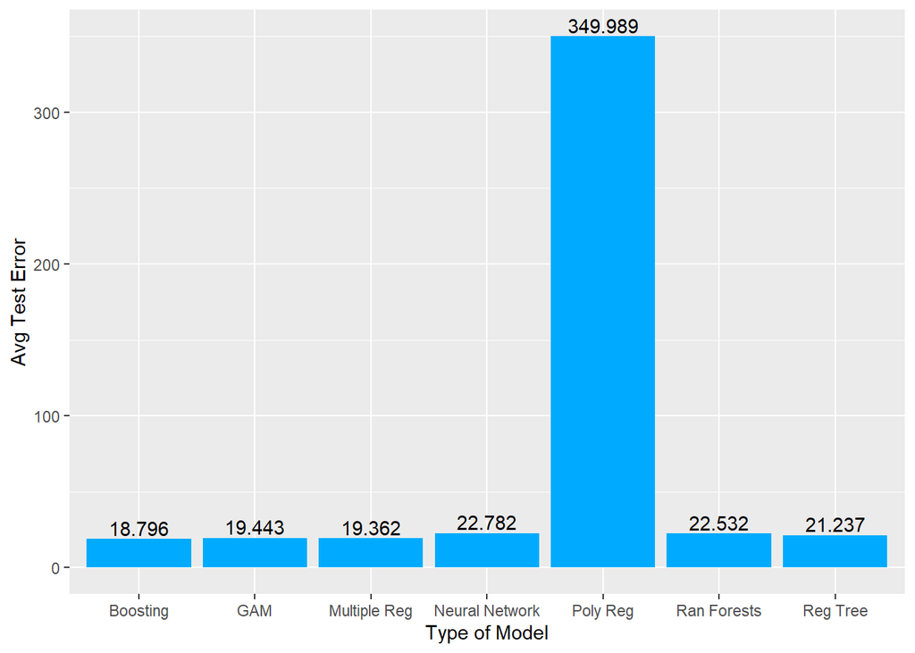

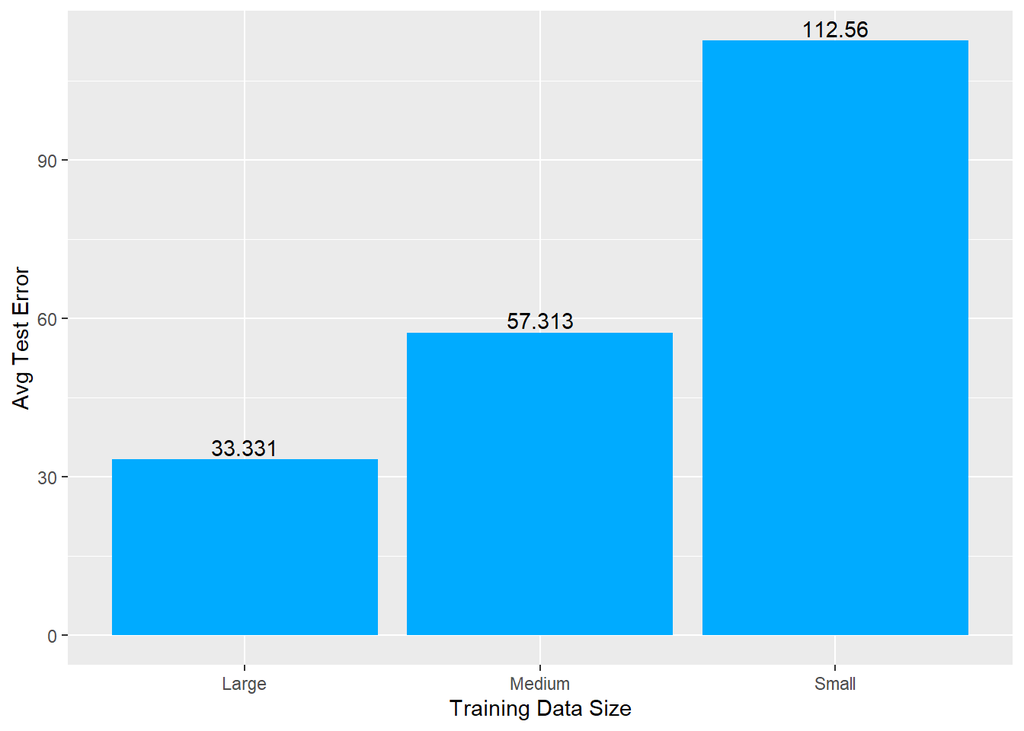

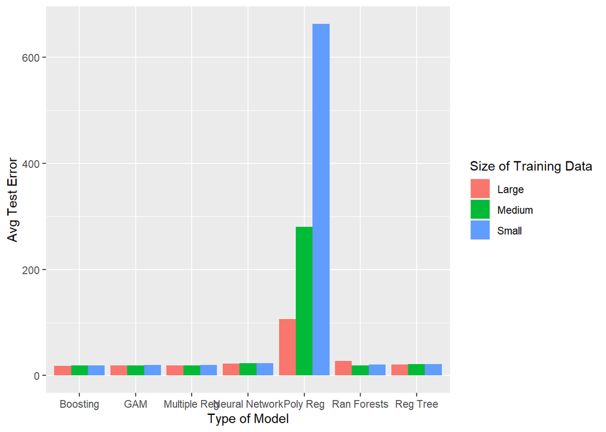

Removing Polynomial Regression to give the other bars appropriate scale:

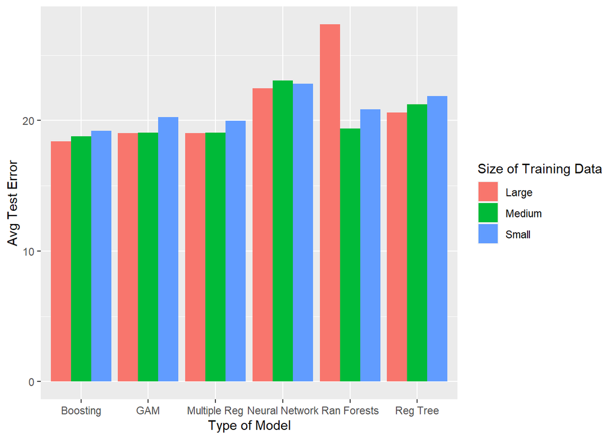

```r
ggplot(data = results[-c(4,5,6),]) + geom_bar(aes(x = Models, y = testerrors, fill = Size), position = 'dodge', stat = 'identity') + labs(x = 'Type of Model', y = 'Avg Test Error')+ scale_fill_discrete(name = 'Size of Training Data')
```